# Pedidos de acesso a informação via LAI no FalaBr

Órgãos e entidades do poder Executivo - 2015 até 2021

```r
library(tidyverse)
library(lubridate)
library(glue)
library(here)
library(ggtext)
library(patchwork)
library(kableExtra)
library(hrbrthemes)
library(tidytext)
```

```r
set.seed(1014)

knitr::knit_hooks$set(inline = function(x) prettyNum(x, big.mark = ".", decimal.mark = ","))

options(
  digits = 1,
  scipen = 999,
  OutDec = ",",
  knitr.kable.NA = "",
  radian.auto_match = FALSE
)

Sys.setenv(LANGUAGE = "pt-br")
Sys.setlocale("LC_TIME", "pt_BR")
```

```
#> [1] ""
```

```r
# helper
`%notin%` <- function(x, y) !(x %in% y)
```

```r
# aplica identidade visual da TB/AeP:
source(here("src/0-paleta-de-cores.R"), encoding = "UTF-8")

theme_set(theme_minimal())

theme_update(
  panel.grid.minor = element_blank(),
  panel.background = element_rect(fill = "gray97", color = "transparent")
)
```

Análises de pedidos de acesso a informação via LAI considerando a decisão de acesso.

```r
pedidos_painel <- "dados/load/rds/base-cgu.rds" %>%
  here() %>%
  readRDS() %>%
  pluck("pedidos") %>%
  janitor::clean_names() %>%
  mutate(
    ts_registro = data_registro,
    ts_resposta = data_resposta,
    data_registro = dmy(data_registro) %>% floor_date(unit = "month"),
    data_resposta = dmy(data_resposta) %>% floor_date(unit = "month")) %>%
  rename(orgao = orgao_destinatario) %>%
  filter(!is.na(decisao),
         !is.na(data_resposta),
         data_registro < ymd("2021-10-01"),
         esfera == "Federal")
```

```r
duplicada <- pedidos_painel %>%
  select(id_pedido, decisao) %>%
  filter(decisao == "Pergunta Duplicada/Repetida") %>%
  nrow()

nao_pedido <- pedidos_painel %>%
  select(id_pedido, decisao) %>%
  filter(decisao == "Não se trata de solicitação de informação") %>%
  nrow()

pedidos_lai <- pedidos_painel %>%
  select(id_pedido, decisao) %>%
  filter(decisao %notin% c(
    "Pergunta Duplicada/Repetida",
    "Não se trata de solicitação de informação"
  )) %>% nrow()

total <- duplicada + nao_pedido + pedidos_lai
```

## Análise de pedidos por decisão de acesso

```r
glimpse(pedidos_painel)
```

```
#> Rows: 1.071.664
#> Columns: 24
#> $ id                    <int> 1, 1, 1, 1, 1, 1, 1, 1, 1, 1, 1, 1, 1, 1, 1, 1, ~
#> $ path                  <chr> "C:/Users/rauld/Documents/negativas-acesso-infor~
#> $ ano                   <chr> "2012", "2012", "2012", "2012", "2012", "2012", ~
#> $ id_pedido             <chr> "1346790", "1346791", "1346792", "1346793", "134~
#> $ protocolo_pedido      <chr> "18600000027201241", "08850000004201231", "08850~
#> $ esfera                <chr> "Federal", "Federal", "Federal", "Federal", "Fed~
#> $ uf                    <chr> "", "", "", "", "", "", "", "", "", "", "", "", ~
#> $ municipio             <chr> "", "", "", "", "", "", "", "", "", "", "", "", ~
#> $ orgao                 <chr> "BACEN – Banco Central do Brasil", "MJSP – Minis~
#> $ situacao              <chr> "Concluída", "Concluída", "Concluída", "Concluíd~
#> $ data_registro         <date> 2012-05-01, 2012-05-01, 2012-05-01, 2012-05-01,~
#> $ prazo_atendimento     <chr> "05/06/2012", "05/06/2012", "05/06/2012", "05/06~
#> $ foi_prorrogado        <chr> "Não", "Não", "Não", "Não", "Não", "Não", "Não",~
#> $ foi_reencaminhado     <chr> "Não", "Não", "Não", "Não", "Não", "Não", "Não",~
#> $ forma_resposta        <chr> "Pelo sistema (com avisos por email)", "Correspo~
#> $ origem_solicitacao    <chr> "Internet", "Internet", "Internet", "Internet", ~
#> $ id_solicitante        <chr> "2104514", "2104756", "2104759", "2104759", "210~
#> $ assunto_pedido        <chr> "Outros em Economia e Finanças", "Abastecimento"~
#> $ data_resposta         <date> 2012-05-01, 2012-06-01, 2012-06-01, 2012-06-01,~
#> $ decisao               <chr> "Acesso Negado", "Acesso Parcialmente Concedido"~
#> $ especificacao_decisao <chr> "Pedido incompreensível", "Parte da informação i~
#> $ sub_assunto_pedido    <chr> NA, NA, NA, NA, NA, NA, NA, NA, NA, NA, NA, NA, ~
#> $ ts_registro           <chr> "15/05/2012", "15/05/2012", "15/05/2012", "15/05~
#> $ ts_resposta           <chr> "16/05/2012", "01/06/2012", "05/06/2012", "05/06~
```

A Decisão de acesso corresponde ao tipo de resposta dada ao pedido (ver [dicionário](http://www.consultaesic.cgu.gov.br/arquivosRelatorios/PedidosRespostas/Dicionario-Dados-Exportacao.txt)).

São considerados pedidos de acesso a informação, pedidos com a decisão:

- Acesso Concedido
- Acesso Parcialmente Concedido
- Acesso Negado
- Órgão não tem competência para responder sobre o assunto

```r
plot_lai_a_partir_de <- function(ano_inicio) {

  ano_inicio <- ano_inicio
  data_de <- ymd(glue("{ano_inicio}-01-01"))
  data_ate <- ymd("2022-01-01")
  data_sequencia <- seq(data_de, data_ate, by = 'year')

  pedidos_painel %>%
    filter(data_registro >= data_de) %>%
    mutate(is_pedido_de_informacao = case_when(
      decisao %notin% c(
        "Pergunta Duplicada/Repetida",
        "Não se trata de solicitação de informação"
      ) ~ "Pedidos de acesso a informação via LAI",
      TRUE ~ decisao
      ) %>% str_wrap(25)) %>%
    count(data_registro, is_pedido_de_informacao, name = "qt") %>%
    ggplot(aes(
      x = data_registro,
      y = qt,
      fill = is_pedido_de_informacao,
      color = is_pedido_de_informacao
    )) +
    geom_vline(xintercept = data_sequencia, lty = 3) +
    geom_line(size = 1.5) +
    geom_label(
      aes(label = qt),
      color = "black",
      size = 3,
      nudge_y = 250,
      alpha = .6,
      label.size = NA,
      data = . %>%
        group_by(is_pedido_de_informacao) %>%
        filter(qt == max(qt)) %>%
        ungroup(),
        show.legend = F
    ) +
    geom_point(
      color = "gray20",
      data = . %>%
        group_by(is_pedido_de_informacao) %>%
        filter(qt == max(qt)) %>%
        ungroup(),
      show.legend = FALSE
    ) +
    geom_text(
      data = . %>% filter(month(data_registro) == 2),
      aes(label = year(data_registro), y = -200),
      size = 3.5,
      vjust = 1.3,
      hjust = .25,
      color = "gray20",
      show.legend = F
    ) +
    scale_fill_manual(values = cores_lai) +
    scale_color_manual(values = cores_lai, breaks = names(cores_lai)[c(3,1,2)]) +
    scale_x_date(
      breaks = scales::date_breaks("3 months"),
      date_labels = "%b",
      expand = c(0, 0)) +
    labs(
      y = "Quantidade",
      x = NULL,
      fill = NULL,
      color = NULL,
      title = "Manifestações para ógãos e entidades do governo executivo Federal",
      subtitle = "Quantidades por mês"
    ) +
    theme(
      legend.position = "top",
      legend.justification = "left",
      legend.text = element_text(margin = margin(2, 5, 2, 5, "pt"))
    )
}
```

### A partir de 2013

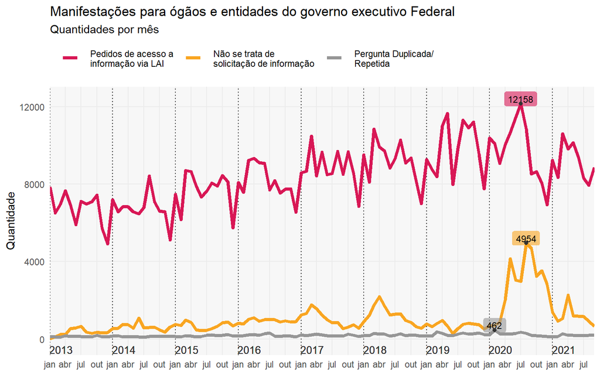

```r
plot_lai_a_partir_de("2013")
```

### A partir de 2015

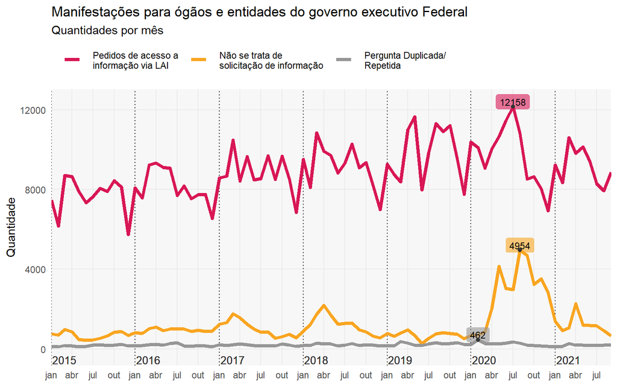

```r
plot_lai_a_partir_de("2015")
```

# Histórico de pedidos de acesso a informação por decisão de acesso

- **Descartar:** “Pergunta duplicada/repetida” e “Não se trata de solicitação de informação”
- **Calcular** a proporção de “Acesso Concedido”, “Acesso Negado” e “Acesso Parcialmente Concedido” em relação ao que sobra sem as categorias acima

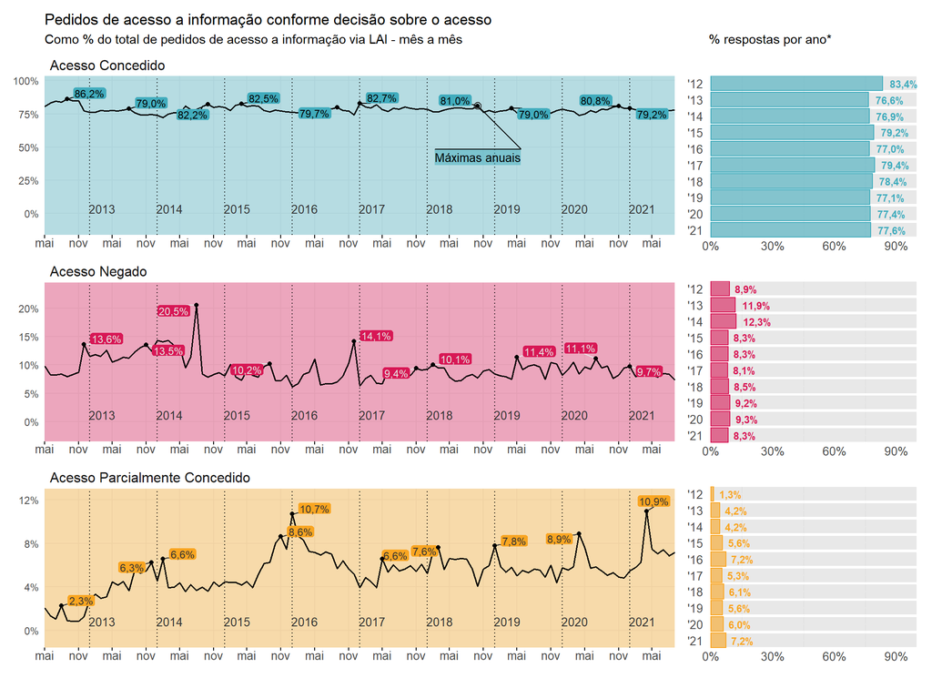

```r
# tipo respostas mais comuns histórico -----------------------------------------
decisao <- pedidos_painel %>%
  filter(decisao %notin% c(
    "Pergunta Duplicada/Repetida",
    "Não se trata de solicitação de informação"
  )) %>%
  count(data_registro, decisao, name = "qt") %>%
  mutate(decisao = fct_reorder(decisao, qt, .desc = T))

my_lbl <- function(x) scales::percent(x, accuracy = .1, decimal.mark = ",")

# plot esquerdo ----------------------------------------------------------------
p1 <- decisao %>%
  add_count(data_registro, wt = qt, name = "qt_mes") %>%
  filter(decisao %in% c(
    "Acesso Concedido",
    "Acesso Negado",
    "Acesso Parcialmente Concedido"
  )) %>%
  mutate(per = qt / qt_mes) %>%
  ggplot(aes(x = data_registro, y = per)) +
  geom_rect(
    data = . %>%
      filter(data_registro == min(data_registro) | data_registro == max(data_registro)),
    aes(
      xmin = min(data_registro),
      xmax = max(data_registro),
      ymin = -Inf,
      ymax = Inf,
      fill = decisao
    ),
    alpha = .2,
    show.legend = F
  ) +
  geom_line(show.legend = F, size = .7) +
  geom_vline(xintercept = seq(ymd('2012-01-01'), ymd('2021-01-01'), by = 'year'), lty = 3) +
  geom_text(
    data = . %>% filter(month(data_registro) == 2),
    aes(label = year(data_registro), y = .005),
    size = 3.5,
    vjust = .1,
    hjust = .25,
    color = "gray20"
  ) +
  ggforce::geom_mark_circle(
    aes(filter = data_registro == ymd("2018-10-01") & decisao == "Acesso Concedido",
        label = "Máximas anuais"),
    color = "gray20",
    fill = NA,
    radius = unit(1, "mm"),
    expand = 0,
    con.cap = 0,
    label.fill = alpha(cores_decisao[["Acesso Concedido"]], .5),
    label.fontsize = 10,
    label.fontface = "plain",
    label.buffer = unit(10, "mm"),
    label.margin = margin(1, 0, 1, 0, "mm")
  ) +
  ggrepel::geom_label_repel(
    data = . %>%
      group_by(decisao, year(data_registro)) %>%
      arrange(year(data_registro), decisao, -per) %>%
      filter(row_number() == 1) %>%
      ungroup(),
    aes(label = my_lbl(per), fill = decisao, color = decisao),
    min.segment.length = 0.01,
    size = 3.2,
    label.padding = unit(0.1, "lines"),
    label.size = NA,
    show.legend = F
  ) +
  geom_point(
    data = . %>%
      group_by(decisao, year(data_registro)) %>%
      arrange(year(data_registro), decisao, -per) %>%
      filter(row_number() == 1) %>%
      ungroup()
  ) +
  scale_fill_manual(values = cores_decisao) +
  scale_color_manual(values = cores_decisao3) +
  scale_y_percent(expand = c(0.2, 0)) +
  scale_x_date(
    breaks = scales::date_breaks("6 months"),
    date_labels = "%b",
    expand = c(0, 0)
  ) +
  theme(
    legend.position = "top",
    axis.ticks.x = element_line(),
    legend.text = element_text(size = 8),
    axis.text.x = element_text(size = 10, vjust = 2.5, hjust = .5),
    panel.grid.minor = element_blank(),
    strip.text = element_text(size = 12, angle = 0, hjust = 0)
  ) +
  labs(
    x = NULL,
    y = NULL,
    title = "Pedidos de acesso a informação conforme decisão sobre o acesso",
    subtitle = "Como % do total de pedidos de acesso a informação via LAI - mês a mês",
    color = NULL,
    fill = NULL
  ) +
  facet_wrap(~ reorder(decisao, -qt), scales = 'free', ncol = 1)

# plot direito -----------------------------------------------------------------
p2 <- decisao %>%
  count(ano = year(data_registro), decisao, wt = qt, name = "qt") %>%
  add_count(ano, wt = qt, name = "qt_ano") %>%
  mutate(perc_ano = qt / qt_ano) %>%
  filter(decisao %in% c(
    "Acesso Concedido",
    "Acesso Negado",
    "Acesso Parcialmente Concedido"
  )) %>%
  ggplot(aes(x = perc_ano, y = reorder(ano, -ano), fill = decisao, color = decisao)) +
  facet_wrap(~ reorder(decisao, -perc_ano), ncol = 1, scales = "free_x") +
  geom_col(aes(x = 1), alpha = .3, fill = "gray70", color = "white") +
  geom_col(alpha = .6) +
  geom_text(aes(label = my_lbl(perc_ano)),
             size = 3, fontface = "bold", hjust = -.25, check_overlap = T) +
  theme_minimal() +
  scale_fill_manual(values = cores_decisao) +
  scale_color_manual(values = cores_decisao2) +
  scale_x_percent(breaks = c(0,.3, .6, .9)) +
  scale_y_discrete(labels = glue("'{21:12}"), expand = c(0, 0)) +
  #coord_flip() +
  theme(
    plot.subtitle = element_text(),
    panel.grid.major.y = element_line(color = "white"),
    panel.grid.major.x = element_blank(),
    panel.grid.minor.y = element_line(color = "white"),
    panel.background = element_blank(),
    strip.text = element_text(color = "transparent"),
    axis.text.x = element_text(size = 10, vjust = 2),
    axis.text.y = element_text(size = 10, hjust = 3)
  ) +
  labs(
    x = NULL,
    y = NULL,
    fill = NULL,
    subtitle = "% respostas por ano*"
  )

comb <- p1 + p2 & theme(legend.position = "none")
comb +
  plot_layout(widths = c(3, 1))
```

```r
# tipo respostas mais comuns histórico -----------------------------------------
decisao <- pedidos_painel %>%
  filter(decisao %notin% c(
    "Pergunta Duplicada/Repetida",
    "Não se trata de solicitação de informação"
  )) %>%
  count(data_registro, decisao, name = "qt") %>%
  mutate(decisao = fct_reorder(decisao, qt, .desc = T))

my_lbl <- function(x) scales::percent(x, accuracy = .1, decimal.mark = ",")

# plot esquerdo ----------------------------------------------------------------
p <- function(decisao_escolhida) {

  p1 <- decisao %>%
    add_count(data_registro, wt = qt, name = "qt_mes") %>%
    filter(decisao %in% c(
      "Acesso Concedido",
      "Acesso Negado",
      "Acesso Parcialmente Concedido"
    )) %>%
    mutate(per = qt / qt_mes) %>%
    filter(decisao == decisao_escolhida) %>%
    ggplot(aes(x = data_registro, y = per)) +
    geom_rect(
      data = . %>%
        filter(data_registro == min(data_registro) | data_registro == max(data_registro)),
      aes(
        xmin = min(data_registro),
        xmax = max(data_registro),
        ymin = -Inf,
        ymax = Inf,
        fill = decisao
      ),
      alpha = .2,
      show.legend = F
    ) +
    geom_line(show.legend = F, size = .7) +
    geom_vline(xintercept = seq(ymd('2012-01-01'), ymd('2021-01-01'), by = 'year'), lty = 3) +
    geom_text(
      data = . %>% filter(month(data_registro) == 2),
      aes(label = year(data_registro),
          y = if_else(decisao == "Acesso Concedido", .65, .005)),
      size = 3.5,
      vjust = .1,
      hjust = .1,
      color = "gray20"
    ) +
    ggforce::geom_mark_circle(
      aes(filter = data_registro == ymd("2018-10-01") & decisao == "Acesso Concedido",
          label = "Máximas anuais"),
      color = "gray20",
      fill = NA,
      radius = unit(1, "mm"),
      expand = 0,
      con.cap = 0,
      label.fill = alpha(cores_decisao[["Acesso Concedido"]], .5),
      label.fontsize = 10,
      label.fontface = "plain",
      label.buffer = unit(10, "mm"),
      label.margin = margin(1, 0, 1, 0, "mm")
    ) +
    ggrepel::geom_label_repel(
      data = . %>%
        group_by(decisao, year(data_registro)) %>%
        arrange(year(data_registro), decisao, -per) %>%
        filter(row_number() == 1) %>%
        ungroup(),
      aes(label = my_lbl(per), fill = decisao, color = decisao),
      min.segment.length = 0.01,
      size = 3.5,
      label.padding = unit(0.1, "lines"),
      label.size = NA,
      show.legend = F
    ) +
    geom_point(
      data = . %>%
        group_by(decisao, year(data_registro)) %>%
        arrange(year(data_registro), decisao, -per) %>%
        filter(row_number() == 1) %>%
        ungroup()
    ) +
    scale_fill_manual(values = cores_decisao) +
    scale_color_manual(values = cores_decisao3) +
    scale_y_percent(expand = c(0.2, 0)) +
    scale_x_date(
      breaks = scales::date_breaks("6 months"),
      date_labels = "%b",
      expand = c(0, 0)
    ) +
    theme_minimal() +
    theme(
      legend.position = "top",
      axis.ticks.x = element_line(),
      legend.text = element_text(size = 8),
      axis.text.x = element_text(size = 11, vjust = 2.5, hjust = .5),
      axis.text.y = element_text(size = 11),
      panel.grid.minor = element_blank(),
      strip.text = element_text(size = 14, angle = 0, hjust = 0)
    ) +
    labs(
      x = NULL,
      y = NULL,
      title = "Pedidos de acesso a informação conforme decisão sobre o acesso",
      subtitle = "Como % do total de pedidos de acesso a informação via LAI - mês a mês",
      color = NULL,
      fill = NULL
    ) +
    facet_wrap(~ reorder(decisao, -qt), scales = 'free', ncol = 1)

  p2 <- decisao %>%
    count(ano = year(data_registro), decisao, wt = qt, name = "qt") %>%
    add_count(ano, wt = qt, name = "qt_ano") %>%
    mutate(perc_ano = qt / qt_ano) %>%
    filter(decisao %in% c(
      "Acesso Concedido",
      "Acesso Negado",
      "Acesso Parcialmente Concedido"
    )) %>%
    filter(decisao == decisao_escolhida) %>%
    ggplot(aes(x = perc_ano, y = reorder(ano, -ano), fill = decisao, color = decisao)) +
    facet_wrap(~ reorder(decisao, -perc_ano), ncol = 1, scales = "free_x") +
    geom_col(aes(x = 1), alpha = .3, fill = "gray97", color = "white") +
    geom_col(alpha = .6) +
    geom_text(aes(label = my_lbl(perc_ano)),
               size = 4, fontface = "bold", hjust = -.05, check_overlap = T) +
    theme_minimal() +
    scale_fill_manual(values = cores_decisao) +
    scale_color_manual(values = cores_decisao2) +
    scale_x_percent(breaks = c(0,.3, .6, .9)) +
    scale_y_discrete(labels = glue("{2021:2012}"), expand = c(0, 0)) +
    #coord_flip() +
    theme(
      plot.subtitle = element_text(),
      panel.grid.major.y = element_line(color = "white"),
      panel.grid.major.x = element_blank(),
      panel.grid.minor.y = element_line(color = "white"),
      panel.background = element_blank(),
      strip.text = element_text(color = "transparent"),
      axis.text.x = element_text(size = 10, vjust = 2),
      axis.text.y = element_text(size = 10, hjust = 3)
    ) +
    labs(
      x = NULL,
      y = NULL,
      fill = NULL,
      subtitle = "% respostas por ano*"
    )

  comb <- p1 + p2 & theme(legend.position = "none")

  comb <- comb +
    plot_layout(ncol = 2, widths = c(2.8, 1.2))

  return(comb)

}
```

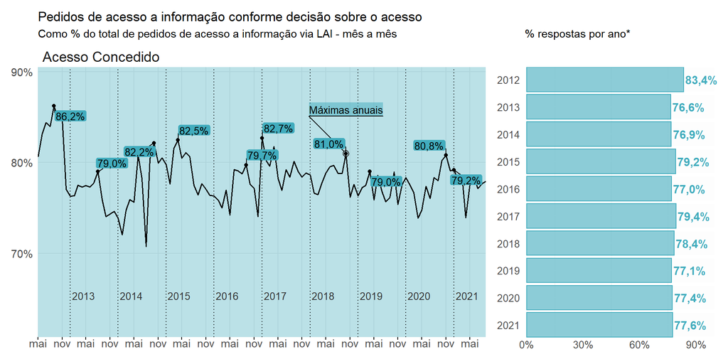

```r
p("Acesso Concedido")
```

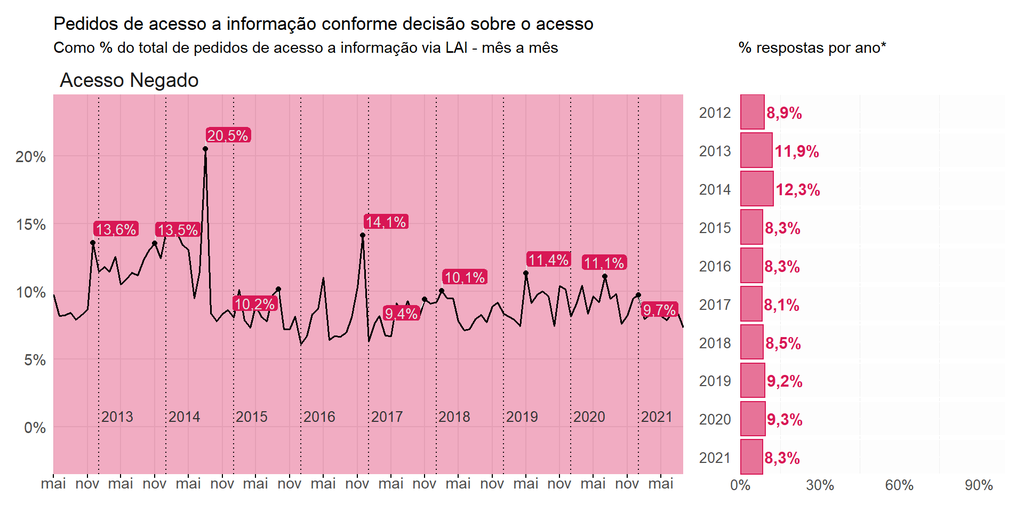

```r
p("Acesso Negado")
```

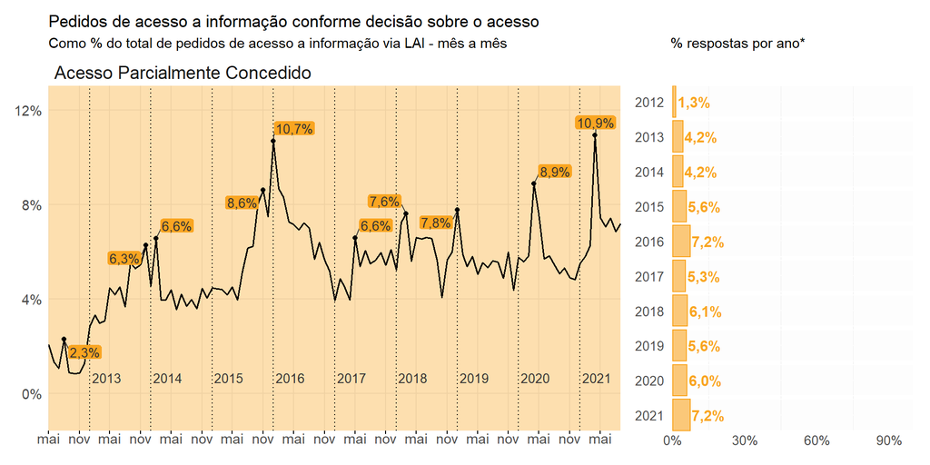

```r
p("Acesso Parcialmente Concedido")
```

## Negativas de acesso a informação

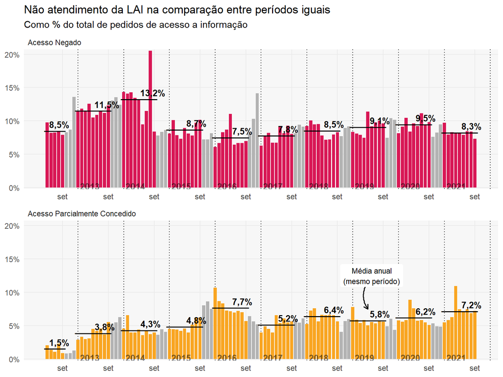

```r
decisao %>%
  mutate(mesmo_periodo = month(data_registro) <= 9) %>%
  add_count(data_registro, mesmo_periodo, wt = qt, name = "qt_mes") %>%
  mutate(perc = qt / qt_mes) %>%
  # filter(decisao == "Acesso Negado") %>%
  filter(decisao %in% c(
    "Acesso Negado",
    "Acesso Parcialmente Concedido"
  )) %>%
  group_by(ano = year(data_registro), mesmo_periodo, decisao) %>%
  mutate(media_perc = if_else(mesmo_periodo, mean(perc), NA_real_)) %>%
  ungroup() %>%
  mutate(
   decisao2 = if_else(mesmo_periodo, as.character(decisao), "")
  ) %>%
  ggplot(aes(x = data_registro, y = perc, fill = decisao2)) +
  geom_vline(
    xintercept = seq(ymd("2013-01-01"), ymd("2022-01-01"), by = "year"),
    lty = 3
  ) +
  geom_col() +
  geom_text(
    data = . %>% filter(month(data_registro) == 2),
    aes(label = year(data_registro), y = .002),
    size = 3.5,
    fontface = "bold",
    hjust = 0.1,
    alpha = .5
  ) +
  geom_point(aes(y = media_perc), shape = 95, size = 4) +
  geom_text(
    data = . %>% filter(month(data_registro) == 6),
    check_overlap = TRUE,
    fontface = "bold",
    size = 3.5,
    aes(
      y = media_perc,
      label = my_lbl(media_perc)
      ),
    nudge_y = .01,
    hjust = .1,
  ) +
  geom_curve(
    data = . %>% filter(decisao2 == "Acesso Parcialmente Concedido"),
    aes(x = ymd("2019-05-01"),
        y = 0.115,
        xend = ymd("2019-05-01"),
        yend = 0.075),
    colour = "black",
    size = 0.6,
    curvature = .35,
    arrow = arrow(length = unit(0.2, "cm"))
  ) +
  geom_label(
    data = . %>% filter(data_registro == ymd("2019-06-01") & decisao2 == "Acesso Parcialmente Concedido"),
    aes(label = "Média anual\n(mesmo período)", y = .125),
    fill = "white",
    size = 3,
    label.size = NA
  ) +
  scale_fill_manual(values = c("gray70", cores_decisao[c(3, 4)])) +
  facet_wrap(. ~ reorder(decisao, -perc), ncol = 1, scales = "free_x") +
  hrbrthemes::scale_y_percent() +
  scale_x_date(
    breaks = ymd(c(glue("{2012:2021}-09-01"), glue("{2012:2021}-09-01"))),
    date_labels = "%b"
    ) +
  theme(
    legend.position = "none",
    panel.grid.minor = element_blank(),
    strip.text = element_text(hjust = 0)
  ) +
  labs(
    x = NULL,
    y = NULL,
    title = "Não atendimento da LAI na comparação entre períodos iguais",
    subtitle = "Como % do total de pedidos de acesso a informação"
  )
```

## Análise de decisão “Não se trata de do solicitação de informação”

A tabela abaixo mostra os assuntos e os órgãos que classificaram manifestações no FalaBr com “Não se trata de do solicitação de informação”. Contou-se o número de vezes que cada órgão classificou uma manifestação em um ano como “não se trata de solicitação de informação”, para cada assunto. A contagem dos órgãos/assuntos/ano foi ordenada do maior para o menor e as 100 primeiras linhas foram selecionadas.

```r
assunto <- pedidos_painel %>%
  filter(decisao == "Não se trata de solicitação de informação") %>%
  select(id_pedido, decisao, data_registro, assunto_pedido, orgao) %>%
  count(
    `Ano` = as.character(year(data_registro)),
    `Assunto do pedido` = assunto_pedido,
    `Órgão` = orgao,
    name = "Quantidade de pedidos por ano",
    sort = T
  )

library(reactable)
assunto %>%
  ungroup() %>%
  slice_max(order_by = `Quantidade de pedidos por ano`, n = 100) %>%
  reactable(
    filterable = T,
    searchable = T,
    defaultSortOrder = "desc",
    defaultSorted = c("Quantidade de pedidos por ano"),
  )
```

| Ano | Assunto do pedido | Órgão | Quantidade de pedidos por ano |
| --- | --- | --- | --- |
| 2020 | Auxílio | MCIDADANIA - Ministério da Cidadania (Desenvolvimento Social e Esporte) | 9769 |
| 2020 | Coronavírus (COVID-19) | MCIDADANIA - Ministério da Cidadania (Desenvolvimento Social e Esporte) | 6633 |
| 2021 | Auxílio | MCIDADANIA - Ministério da Cidadania (Desenvolvimento Social e Esporte) | 5557 |
| 2017 | Outros em Economia e Finanças | ME - Ministério da Economia | 4581 |
| 2016 | Outros em Economia e Finanças | ME - Ministério da Economia | 4496 |
| 2018 | Acesso à informação | ECT – Empresa Brasileira de Correios e Telégrafos | 3153 |
| 2018 | Outros em Economia e Finanças | ME - Ministério da Economia | 2798 |
| 2015 | Outros em Economia e Finanças | ME - Ministério da Economia | 2785 |
| 2020 | Coronavírus (COVID-19) | CEF – Caixa Econômica Federal | 2288 |
| 2018 | Outros em Previdência | INSS – Instituto Nacional do Seguro Social | 1916 |

[output cut: 90 more lines]